# Reducción de dimensionalidad y marginación de municipios

## Marginación de municipios

Consideremos el índice de marginación que calcula CONAPO con datos de censos y conteos. Este índice un resumen de varios indicadores de carencias de las poblaciones de los municipios que nos permite rankear u ordenar a los municipios por nivel de marginación. Se utiliza frecuentemente en análisis en donde queremos incluir el contexto donde viven las personas, y para guiar decisiones de política pública.

Por ejemplo, para 2010 tenemos los datos:

```r
library(tidyverse)
marginacion <- read_csv("../datos/indice-marginacion/imm-2010.csv")
descrip <- read_csv("../datos/indice-marginacion/imm-2010-descrip.csv", skip = 2)
descrip
```

```
## # A tibble: 16 × 2
##    Variable Descripción
##    <chr>    <chr>
##  1 CVE_ENT  Clave de la entidad federativa
##  2 NOM_ENT  Nombre de la entidad federativa
##  3 CVE_MUN  Clave del municipio
##  4 NOM_MUN  Nombre del municipio
##  5 POB_TOT  Población total
##  6 ANALF    Porcentaje de población de 15 años o más analfabeta
##  7 SPRIM    Porcentaje de población de 15 años o más sin primaria completa
##  8 OVSDE    Porcentaje de ocupantes en viviendas sin drenaje ni excusado
##  9 OVSEE    Porcentaje de ocupantes en viviendas sin energía eléctrica
## 10 OVSAE    Porcentaje de ocupantes en viviendas sin agua entubada
## 11 VHAC     Porcentaje de viviendas con algún nivel de hacinamiento
## 12 OVPT     Porcentaje de ocupantes en viviendas con piso de tierra
## 13 PL_5000  Porcentaje de población en localidades con menos de 5 000 habitantes
## 14 PO2SM    Porcentaje de población ocupada con ingreso de hasta 2 salarios mín…
## 15 IM       Índice de marginación
## 16 GM       Grado de marginación
```

El índice de marginación es una combinación de variables que indican distintos tipos de carencias para obtener un resumen o calificación general del grado de marginación de **cada municipio**.

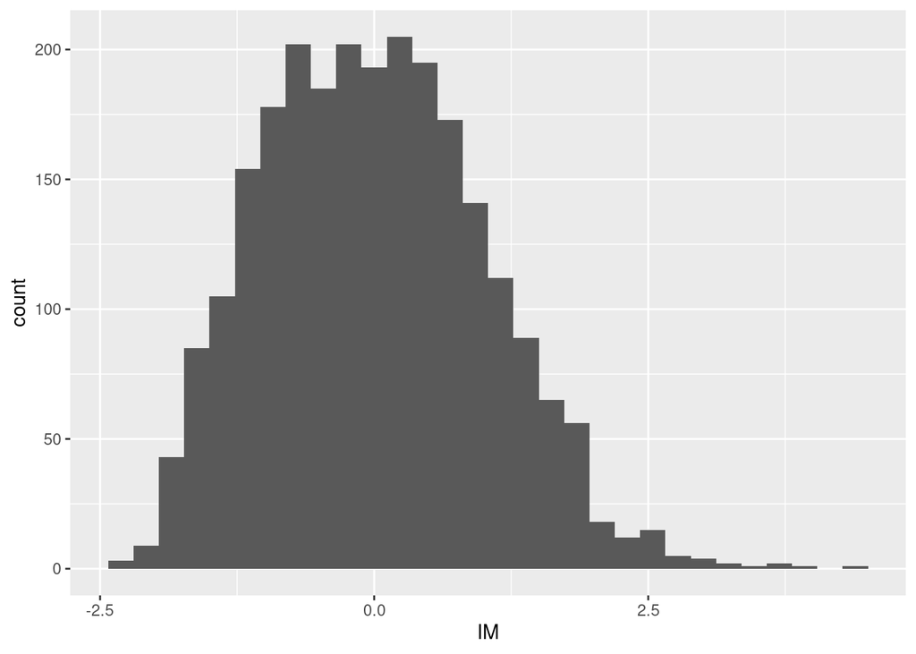

```r
ggplot(marginacion, aes(x = IM)) + geom_histogram()
```

Por ejemplo, si promediamos los índices de marginación de los municipios dentro de cada estado obtenemos:

```r
marginacion |> group_by(NOM_ENT) |> summarise(marg = mean(IM), n = sum(POB_TOT)) |>
    arrange(desc(marg))
```

```
## # A tibble: 32 × 3
##    NOM_ENT                           marg       n
##    <chr>                            <dbl>   <dbl>
##  1 Guerrero                         1.12  3388768
##  2 Chiapas                          0.808 4796580
##  3 Oaxaca                           0.652 3801962
##  4 Puebla                           0.290 5779829
##  5 Veracruz de Ignacio de la Llave  0.216 7643194
##  6 Yucatan                          0.176 1955577
##  7 San Luis Potosi                  0.114 2585518
##  8 Campeche                        -0.163  822441
##  9 Michoacan de Ocampo             -0.203 4351037
## 10 Hidalgo                         -0.218 2665018
## # … with 22 more rows
```

## Aproximación de rango uno

```r
marginacion
```

```
## # A tibble: 2,456 × 16
##    CVE_MUN CVE_ENT NOM_ENT  NOM_MUN  POB_TOT ANALF SPRIM OVSDE OVSEE OVSAE  VHAC
##    <chr>   <chr>   <chr>    <chr>      <dbl> <dbl> <dbl> <dbl> <dbl> <dbl> <dbl>
##  1 09012   09      Distrit… Tlalpan   650567  2.25  9.46  0.13  0.23 11.4  26.1
##  2 09013   09      Distrit… Xochimi…  415007  2.73  9.92  0.19  0.31  6.69 32.8
##  3 09008   09      Distrit… La Magd…  239086  2.65 11.1   0.1   0.09  3.57 30.8
##  4 09002   09      Distrit… Azcapot…  414711  1.63  7.19  0.03  0.01  0.17 23.4
##  5 09014   09      Distrit… Benito …  385439  0.56  3.06  0.02  0.01  0.04  8.19
##  6 09015   09      Distrit… Cuauhte…  531831  1.44  6.45  0.05  0.05  0.08 19.4
##  7 09010   09      Distrit… alvaro …  727034  2.19  9.43  0.04  0.04  0.76 26.9
##  8 09005   09      Distrit… Gustavo… 1185772  2.17  9.15  0.06  0.04  0.29 27.8
##  9 09004   09      Distrit… Cuajima…  186391  2.37  9.64  0.13  0.08  1.67 29.5
## 10 09016   09      Distrit… Miguel …  372889  1.21  6.02  0.02  0.02  0.03 17.1
## # … with 2,446 more rows, and 5 more variables: OVPT <dbl>, PL_5000 <dbl>,
## #   PO2SM <dbl>, IM <dbl>, GM <chr>
```

Veamos un resumen de las variables incluidas:

```r
marg_tabla <- marginacion |> select(ANALF:PO2SM)
marg_tabla |> gather(variable, valor, ANALF:PO2SM) |> group_by(variable) |>
    summarise(q10 = quantile(valor, 0.10),
              mediana = median(valor),
              q90 = quantile(valor, 0.90)) |>
    arrange(desc(mediana))
```

```
## # A tibble: 9 × 4
##   variable    q10 mediana    q90
##   <chr>     <dbl>   <dbl>  <dbl>
## 1 PL_5000  14.8    100    100
## 2 PO2SM    33.6     63.4   86.2
## 3 VHAC     29.1     43.7   61.8
## 4 SPRIM    16.0     34.5   50.9
## 5 ANALF     3.82    11.9   27.9
## 6 OVPT      1.91     8.68  29.4
## 7 OVSAE     0.665    7.03  40.8
## 8 OVSDE     0.62     3.46  17.9
## 9 OVSEE     0.51     2.18   8.78
```

Nota que la escala de las variables es muy distinta distinta. Podemos normalizar, por ejemplo centrando y escalando por la desviación estándar (esta no es la única manera):

```r
marg_tabla_esc <- marg_tabla |>
  mutate(across(everything(), ~ (.x - mean(.x))/sd(.x)))
```

```r
marg_tabla_esc |> gather(variable, valor, ANALF:OVPT) |> group_by(variable) |>
    summarise(q10 = quantile(valor, 0.10),
              mediana = median(valor),
              q90 = quantile(valor, 0.90)) |>
    arrange(desc(mediana)) |>
  mutate(across(is.numeric, ~ round(.x, 3)))
```

```
## # A tibble: 7 × 4
##   variable    q10 mediana   q90
##   <chr>     <dbl>   <dbl> <dbl>
## 1 SPRIM    -1.41    0.024  1.29
## 2 VHAC     -1.25   -0.085  1.37
## 3 ANALF    -1.06   -0.228  1.43
## 4 OVSEE    -0.567  -0.298  0.76
## 5 OVPT     -0.913  -0.34   1.41
## 6 OVSDE    -0.673  -0.368  1.18
## 7 OVSAE    -0.789  -0.431  1.46
```

- Buscamos primero una dimensión latente que nos da la mejor aproximación de rango uno a la tabla de marginación normalizada.

Para hacer esto podemos usar la descomposición en valores singulares:

```r
dvs_marg <- svd(marg_tabla_esc)
```

Extraemos las componentes de este objeto:

```r
# puedes multipicar columnas particulares de u **y** v por -1 para interpretar más fácilmente
# si es necesario. Si multiplicas por -1 la columna 3 de U, por ejemplo, también
# hay que multiplicar por -1 la columna 3 de V
u <- dvs_marg$u
v <- dvs_marg$v
sigma <- dvs_marg$d
```

**Pregunta 1**: calcula la dimensión o tamaño de u, v y sigma. Explica de dónde salen estos valores.

Respuesta:

```r
dim(u)
```

```
## [1] 2456    9
```

```r
dim(v)
```

```
## [1] 9 9
```

```r
length(sigma)
```

```
## [1] 9
```

Extrae la primera dimensión de esta descomposición:

```r
u_1 <-   u[,1]
v_1 <-   v[,1]
sigma_1 <- sigma[1]
```

Ahora construimos la aproximación de rango 1 a la matriz normalizada de marginación:

```r
X_1 <- sigma_1 * u_1 %*% t(v_1)
```

**Pregunta 2**: Calcula qué tan buena es la aproximación: calcula los residuales de $X_1$ como aproximación de *marg_tabla*, y compara con el tamaño de *marg_tabla*

```r
X <- as.matrix(marg_tabla_esc)
R <- X - X_1
calidad_aproxim <- 1 - sum(R^2)/sum(X^2)
calidad_aproxim
```

```
## [1] 0.5046552
```

Grafica los valores de la aproximación $X_1$ vs $X$

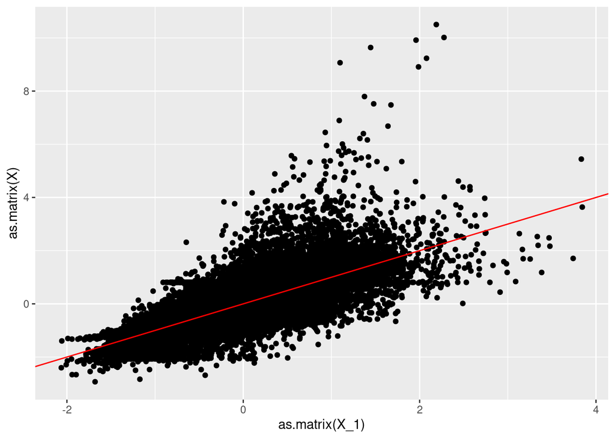

```r
qplot(as.matrix(X_1), as.matrix(X)) + geom_abline(color = "red")
```

**Pregunta 3**: En la descomposición que hiciste, ¿Qué usaría cómo medición de marginación por municipio, los scores de los municipios o los pesos de las variables?

Respuestas: nuestro índice de marginación está dado por la $u$, o por:

$$X_cv = \sigma u$$

**Pregunta 4**: Explica cómo se construye tu medición de marginación en términos de la descomposición en valores singulares que obtuviste? ¿Cómo se ponderan las variables originales para construir tu medición de marginación?

Respuesta: ver arriba

```r
tibble(variable = colnames(X), peso_1 = v_1) |>
  arrange(desc(peso_1))
```

```
## # A tibble: 9 × 2
##   variable peso_1
##   <chr>     <dbl>
## 1 SPRIM     0.413
## 2 ANALF     0.412
## 3 PO2SM     0.402
## 4 VHAC      0.337
## 5 OVPT      0.318
## 6 PL_5000   0.301
## 7 OVSAE     0.271
## 8 OVSEE     0.271
## 9 OVSDE     0.214
```

```r
cor(marg_tabla) |> round(2)
```

```
##         ANALF SPRIM OVSDE OVSEE OVSAE VHAC OVPT PL_5000 PO2SM
## ANALF    1.00  0.88  0.34  0.37  0.42 0.63 0.52    0.46  0.72
## SPRIM    0.88  1.00  0.33  0.37  0.37 0.53 0.48    0.60  0.79
## OVSDE    0.34  0.33  1.00  0.37  0.23 0.34 0.09    0.23  0.26
## OVSEE    0.37  0.37  0.37  1.00  0.43 0.33 0.40    0.28  0.33
## OVSAE    0.42  0.37  0.23  0.43  1.00 0.37 0.41    0.24  0.35
## VHAC     0.63  0.53  0.34  0.33  0.37 1.00 0.44    0.25  0.59
## OVPT     0.52  0.48  0.09  0.40  0.41 0.44 1.00    0.34  0.56
## PL_5000  0.46  0.60  0.23  0.28  0.24 0.25 0.34    1.00  0.62
## PO2SM    0.72  0.79  0.26  0.33  0.35 0.59 0.56    0.62  1.00
```

**Pregunta 5**: ¿Puedes reconstruir el índice oficial a partir de la componente que obtuviste?

Respuesta:

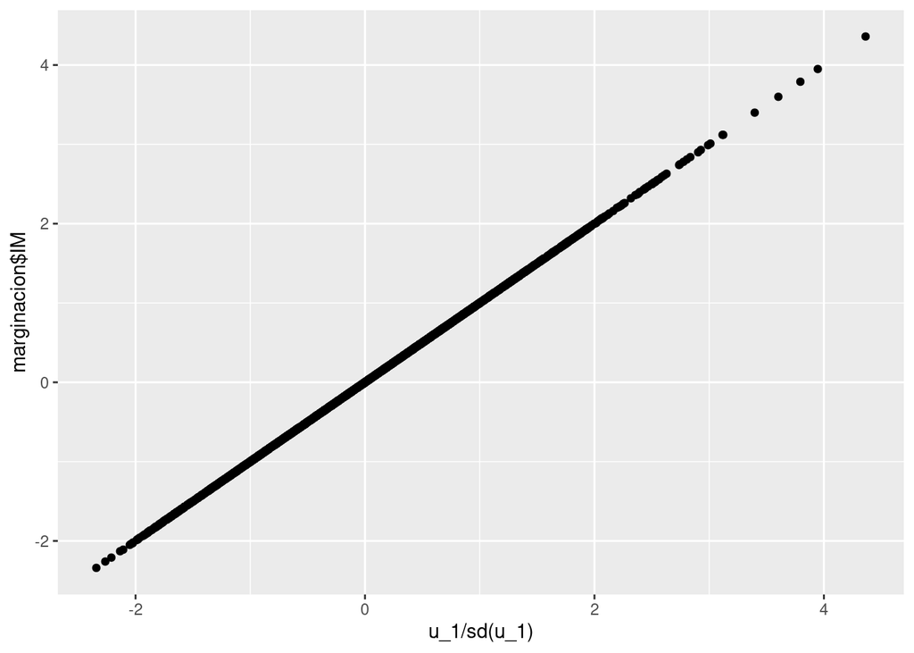

```r
qplot( u_1 / sd(u_1), marginacion$IM)
```

Una forma de graficar los scores junto con el peso de las variables es el *biplot*. Puedes hacerlo como sigue:

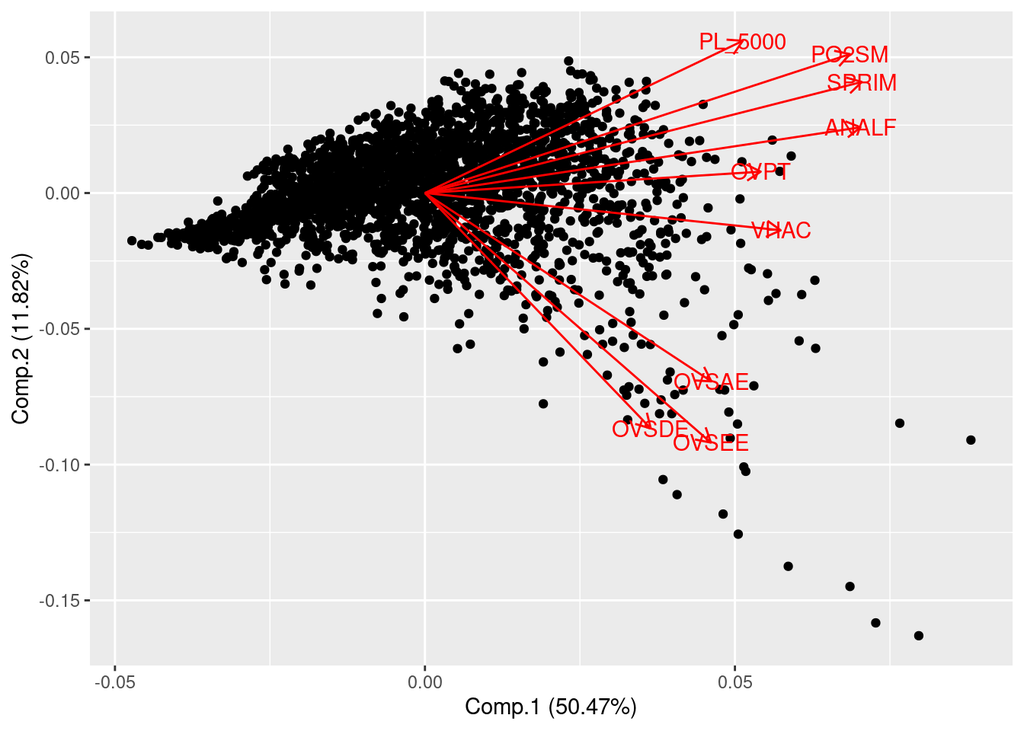

```r
ajuste <- princomp(marg_tabla_esc)
library(ggfortify)
ggplot2::autoplot(ajuste, label = FALSE, loadings.label = TRUE)
```

Interpretamos el biplot como sigue: la proyección de un municipio sobre cada vector (variable original) intenta aproximar el valor que toma cada municipio en la variable correspondiente. En nuestra gráfica, los municipios a la derecha tienden a tener valores más altos que promedio en todas las variables, y los que están a la izquierda están por debajo del promedio. **Recuerda que esta es la aproximación de rango 2, de forma que estas proyecciones dan valores aproximados en relación a los datos originales**.

**Pregunta 6**: Interpreta la segunda dimensión, ¿qué tipo de municipios discrimina?

```r
tibble(variable = colnames(X), peso_1 = v[,2]) |>
  arrange(desc(peso_1))
```

```
## # A tibble: 9 × 2
##   variable  peso_1
##   <chr>      <dbl>
## 1 OVSEE     0.539
## 2 OVSDE     0.509
## 3 OVSAE     0.407
## 4 VHAC      0.0805
## 5 OVPT     -0.0462
## 6 ANALF    -0.142
## 7 SPRIM    -0.240
## 8 PO2SM    -0.300
## 9 PL_5000  -0.329
```

**Nota**: datos atípicos pueden tener mucho peso el resultado del análisis por DVS o componentes principales. Debe ser considerado cuál es una solución más útil: correr el análisis con los datos tal cual, o eliminar los atípicos. Al fin del análisis, siempre podemos proyectar renglones en las dimensiones de $U$ recordando que $x^{(n+1)}\cdot v_k = \sigma_k u_k$.